# Landuse Toolbox Data Exploration

#### How high do the rainfed CIs get?

We expect that the issue causes very high CIs for some cells. The rainfed CIs of 1b are plotted below.

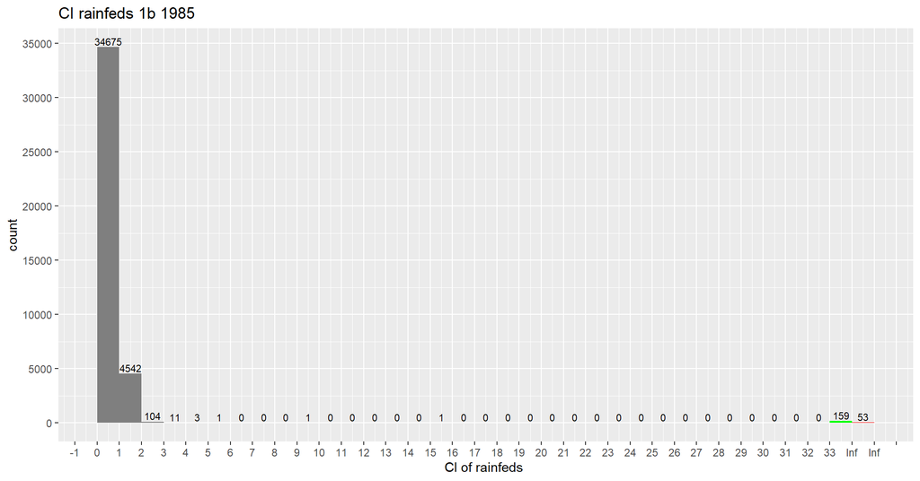

```r
CI_1b[,,"rainfed"] %>% as.data.frame() %>% mutate(multi = Value,perennialHA = 1, physicalTOT =1) -> CIR

CI_1b[,,"irrigated"] %>% as.data.frame() %>% mutate(multi = Value,perennialHA = 1, physicalTOT =1) -> CII


hist_annualCI_multi( "1985", CIR , facet =F,titel= "CI rainfeds 1b 1985", labx = "CI of rainfeds " )
```

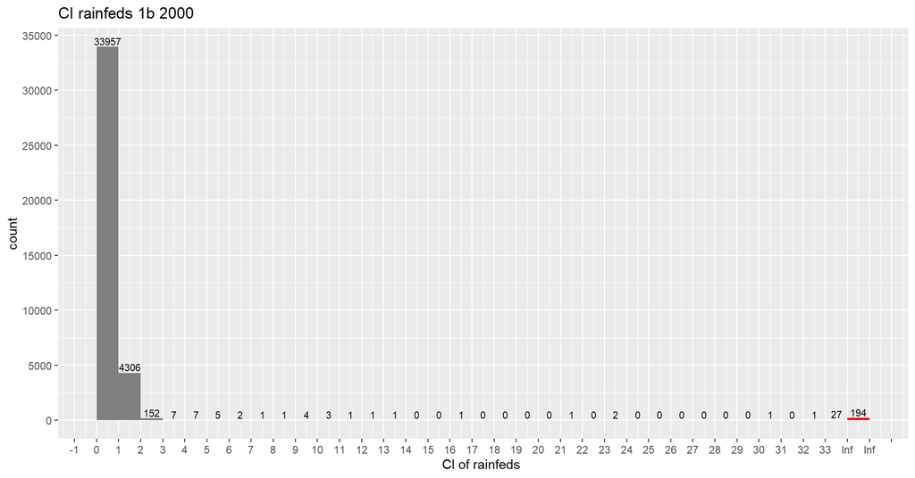

```r
hist_annualCI_multi( "2000", CIR , facet =F,titel= "CI rainfeds 1b 2000", labx = "CI of rainfeds " )
```

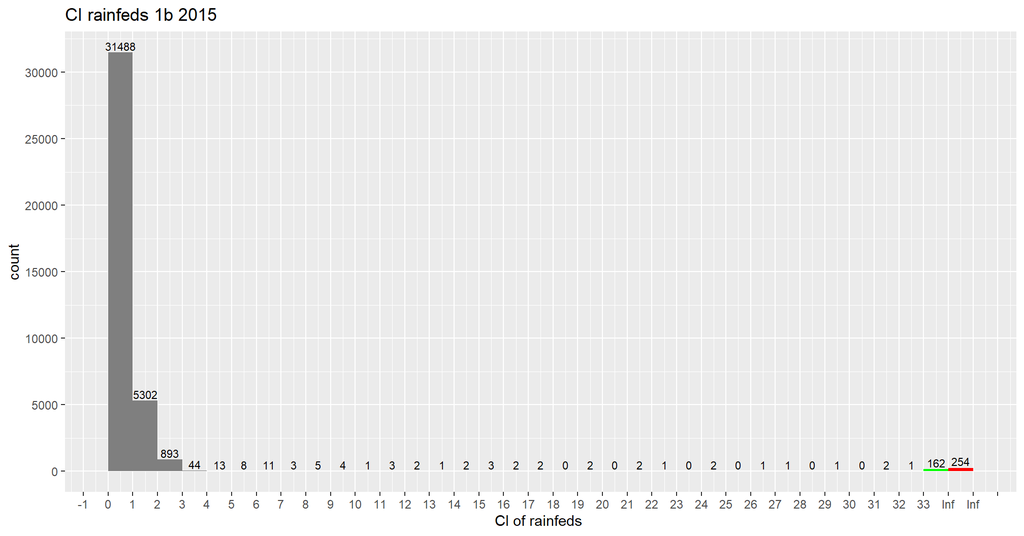

```r
hist_annualCI_multi( "2015", CIR , facet =F,titel= "CI rainfeds 1b 2015", labx = "CI of rainfeds " )
```

For the irrigated hopefully no such problem will arise.

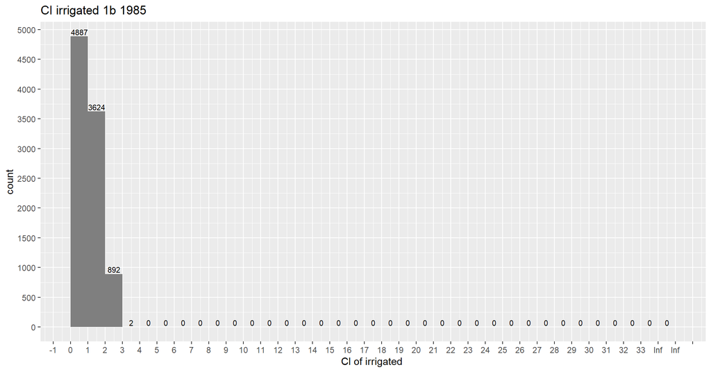

```r
hist_annualCI_multi( "1985", CII , facet =F,titel= "CI irrigated 1b 1985", labx = "CI of irrigated " )
```

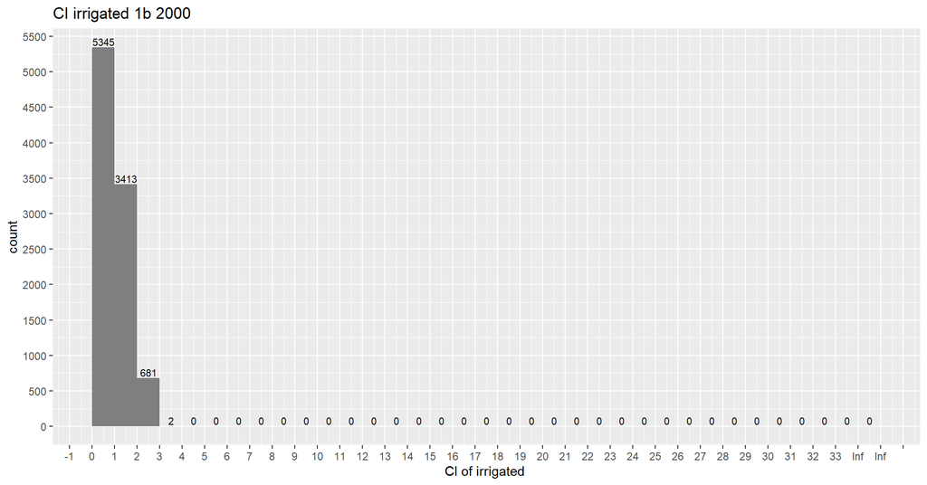

```r
hist_annualCI_multi( "2000", CII , facet =F,titel= "CI irrigated 1b 2000", labx = "CI of irrigated " )
```

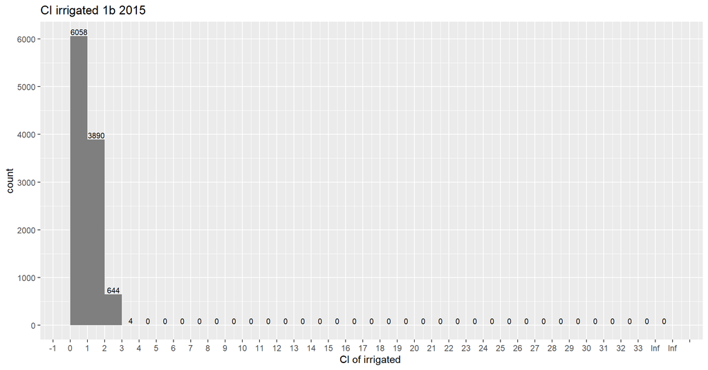

```r
hist_annualCI_multi( "2015", CII , facet =F,titel= "CI irrigated 1b 2015", labx = "CI of irrigated " )
```

In general the irrigated CIs look much more realistic compard to rainfed CIs.

Note that ignoring the unrealistically high rainfed CIs, the relative share of higher CIs is much greater for irrigated crops as compared to rainfed crops. This confirms the expectation from the beginning that irrigated crops should have more multicropping than rainfed crops. It could also be an argument towards using 1b since this difference is lost when using 1a. In other words: Ignoring the outliers, the 1b data reflects the probably factual difference of irrigated crops having higher CIs than rainfed crops, while 1a data does not.